# Part II - Investigating Bike Trip Durations and User Characteristics

[figure not shown]

## by Bukunmi Adebanjo

[figure not shown]

## Investigation Overview

> > - This presentation will explore variables of interest such as gender, start_station, end_station, age,start_time, user types and trip duration. Particularly, how trip duration varies amongst different gender groups,user types and hours of the day. Also, using trip durations as a metric to determine the busiest Start and End bike stations and what gender groups engages these busy stations the most in terms of trip duration.
> > - The presentation will begin with a look at the duration variable, and then I'll gradually introduce other variables to highlight the probable linkages and correlations between them. In other words a flow from Univariate to Bivariate and Multivariate plots will be deployed for this presentation to better communicate necessary insights.

[figure not shown]

## Dataset Overview

> Ford Gobike system Data contains individual rides in a bike-sharing system spanning the larger San Francisco Bay area included in the 'fordgobike-tripdata' data file of over 180,000 records. Contained within the dataset is a total of 16 variables(dependent and non-dependent) before cleaning which was modified to 14 variables afterwards:

```
start_time             object
end_time               object
start_station_id        int64
start_station_name     object
end_station_id          int64
end_station_name       object
bike_id                 int64
user_type              object
member_birth_year       int64
member_gender          object
duration_min          float64
start_time_hr           int64
end_time_hr             int64
member_age              int64
dtype: object
```

[figure not shown]

## Distribution of Trip Duration

> A transformed Duration variable is included in the dataset used for this visualization. This variable, which was originally in seconds, was difficult to understand due to the wide range of integer values, necessitating the conversion to minutes. A log scale was also used to help drill down into this variable and provide a more appropriate depiction. This made it easier to see that the duration variable had a wide range of values, with a peak at about the 10 minutes mark and a minimum trip duration of about 1 minute.

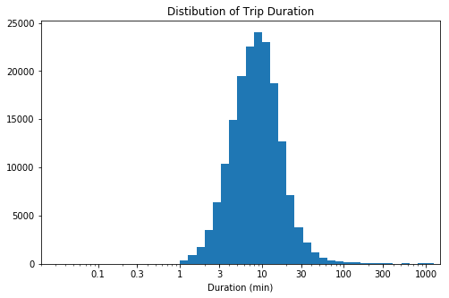

[figure not shown]

## Bike Trips Start Time Distribution & Bike Trips End Time Distribution

> The best times to start travels are at 8 a.m. and 5 p.m. on opposite sides of the day. The majority of bike rides end at 5 p.m. and 8 a.m., respectively. This allows us to identify 8 a.m. and 5 p.m. as the busiest hours of the day for bike stations in the San Francisco Bay Area. This could owe to the fact that the most common trip duration is aroud 10 minutes according to the previous visualisation.

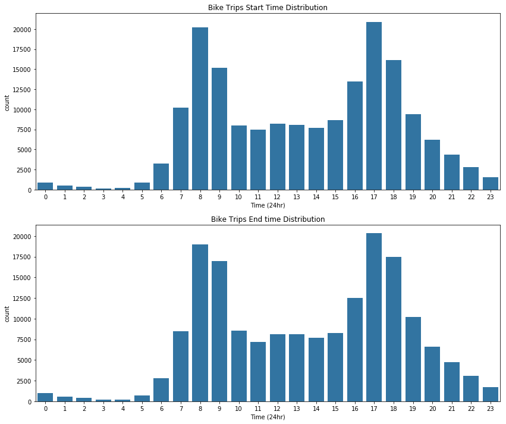

[figure not shown]

## Top Five Busiest (Start and End) Bike Stations

> The top two busiest end stations are 'San Francisco Caltrain Station 2' and 'Market St at 10th St' with both of them switching postions for the start station. Considering the both start and end station, San Francisco Caltrain Station 2 is busiest bike station. It would be intuitive to assume that these two stations are most likely around ten minutes apart based on what the duration distribution chart communicated.

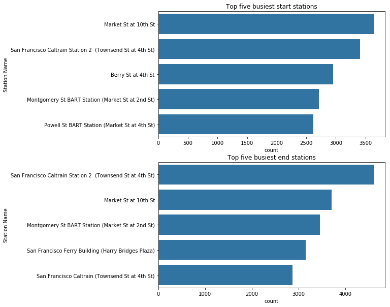

[figure not shown]

## Ride Duration VS Start Time

> Increased correlation is observed as the day progresses and a slight gradual decline in correlation is observed after 5 p.m. Users who started their rides between noon toward the late hours of the day tend to frequently take longer trips as opposed to the early hours of the day. In order words, longer trips are more associated with later hours of the day starting from 1 p.m.

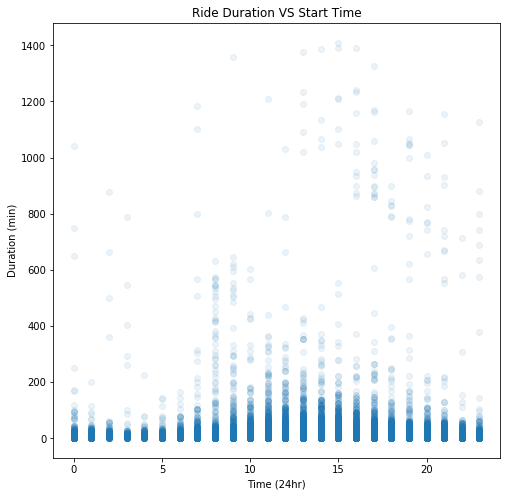

[figure not shown]

## Ride Duration VS User Type/Gender Type

> A majority of the subscriber category members' travel duration fall within the range of 1 to 10 minutes with over 50% falling below 10 minutes. The customer category have slightly over 25% of them with trip durations lower than 10 minutes while the rest fall above the 10 minutes cap. A more spreadout trip duration distribution is obeserved in the customer category type.  
> The 'male', 'female' and 'other' gender types show similiar trip duration distribution regardless of their respective sample size percentage. Majority of the gender class travel between 10 minutes duration and below. `

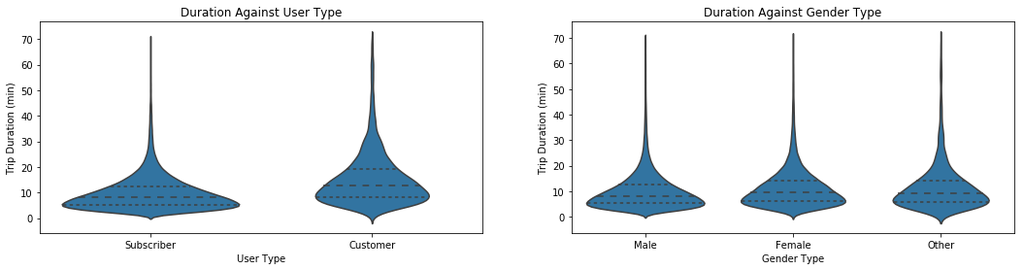

[figure not shown]

## Gender Activity by Minutes Across Top 5 Busiest Start Stations

> A large male gender percentage in the dataset does not directly translate to dominance in all relationships, which surprised me. The 'San Francisco Caltrain Station 2' and 'Powell St BART Station (Market St at 4th St)' stations are the busiest in terms of longer trip durations, this is oweing to the Other gender category as shown in the top 5 busiest start stations. `

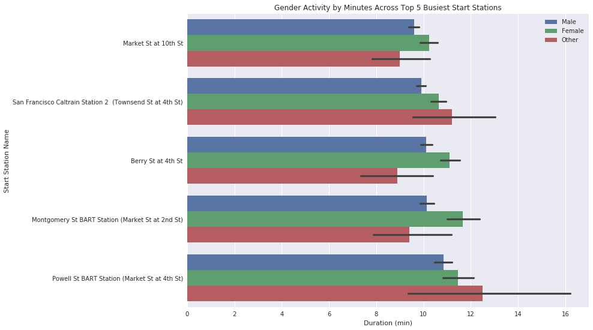